# 231B - Section 4

# 2. Monte Carlo simulation: unbiasedness and omitted variable bias

To prove unbiasedness, we need to show that $E(\hat{\beta})=\beta$.

$$E\big[ \hat{\beta} \mid X \big] = E\big[ (X'X)^{-1}X'Y \mid X \big]$$

Say, however, that the real model is $Y=X\beta+Z\mu+\epsilon$. Then when we substitute for $Y$ we have:

$$\begin{array}
\[E\big[ \hat{\beta} \mid X \big] & = E\big[ (X'X)^{-1}X'(X\beta+Z\mu+\epsilon) \mid X \big] \\
& = E\big[ (X'X)^{-1}X'X\beta+ (X'X)^{-1}X'Z\mu + (X'X)^{-1}X'\epsilon \mid X \big] \\
& = E\big[ (X'X)^{-1}X'X\beta \mid X \big]+ E\big[(X'X)^{-1}X'Z\mu \mid X \big] + E\big[ (X'X)^{-1}X'\epsilon \mid X \big] \\
& = E\big[ \beta \mid X \big] + E\big[(X'X)^{-1}X'Z\mu \mid X \big] + (X'X)^{-1}X'E\big[ \epsilon \mid X \big] \\
& = \beta + \mu(X'X)^{-1}E(X'Z|X) + (X'X)^{-1}X'0 \\
& = \beta + \mu(X'X)^{-1}E(X'Z|X)
\end{array}$$

Let’s take a closer look at $\mu(X'X)^{-1}E(X'Z|X)$

- When $\mu$ is zero, the expression is $0$ and our regression of $Y$ on $X$ allows us to estimate without bias. What does this mean?
- When $X'Z=0$, the correlation between $X$ and $Z$ and the entire expression is also $0$.
- What happens when $X'Z \neq 0$? Can we know anything about the direction or magnitude of the bias?

We will program a simulation to see this. We will need to write a function that takes the following arguments and returns the regression coefficients for the regression we indicate:

- X matrix (more about this later)
- betas: true parameters of the model. Here, $\beta_{0} = 1$, $\beta_{1} = 2$, $\beta_{2} = 4$, $\beta_{3} = 3$
- residuals from other model (e)
- An omitted variable indicator: should we omit the third variable in the regression?

```r
ovb_sim <- function(X, betas, e, omitted=FALSE){

  # Create the simulated y by
  # adding together the systematic and stochastic
  # components, according to the true model
  # note that we are adding column of 1s for the intercept
  y <- cbind(1, X) %*% betas + sample(e, 100, replace=F)

  # Run a regression of the simulated y on the simulated X
  # with the option of omitting x2 or not

  # Extract the estimated coefficients
  coefs <-

  # Return the coefficients
  return(coefs)
}
```

```r
ovb_sim <- function(X, betas, e, omitted=FALSE){

  # Create the simulated y by
  # adding together the systematic and stochastic
  # components, according to the true model
  # note that we are adding column of 1s for the intercept
  y <- cbind(1, X) %*% betas + sample(e, 100, replace=F)

  # Run a regression of the simulated y on the simulated X
  # with the option of omitting x2 or not
  if (omitted==FALSE) res <- lm(y~X) # complete model
  if (omitted==TRUE) res <- lm(y~X[,c(1,2)]) # omitting the third variable

  # Extract the estimated coefficients
  coefs <- res$coefficients

  # Return the coefficients
  return(coefs)
}
```

We will look at four different cases:

1. The three independent variables belong in the real model and they are correlated – and we specify the right regression.
2. The three independent variables belong in the real model and they are correlated (positive covariance) – our regression omits $x_3$
3. The three independent variables belong in the real model and they are correlated (negative covariance) – our regression omits $x_3$
4. The three independent variables belong in the real model but they are not correlated – our regression omits $x_3$

First we will need to create the matrices with the variances and covariances of $X$.

- What is the key thing to consider when we build these matrices?

```r
# True variance-covariance matrices
# Here the off-diagonal elements are zero, so the variables are not correlated
# with each other
SigmaX_without <- matrix(c( 2,  0,  0,
                            0,  2,  0,
                            0,  0,  2 ), nrow=3,
                         ncol=3, byrow=TRUE)
# Now in these the off-diagonal elements are non-zero (the variables are correlated)
SigmaX_with_positive <- matrix(c( 1,  .5,  .5,
                                 .5,   1,  .5,
                                 .5,  .5,   1 ),
                               nrow=3, ncol=3,
                               byrow=TRUE)

SigmaX_with_negative <- matrix(c(  1,  -.5,  -.5,
                                 -.5,    1,  -.5,
                                 -.5,  -.5,    1 ),
                               nrow=3, ncol=3,
                               byrow=TRUE)
```

And now we can use this to generate the `X` matrices (note we use `mvrnorm()`)

```r
# Draw the simulated covariates from their true
# multivariate Normal distribution
X_without <- mvrnorm(n=200, mu=c(0,0,0),
                     Sigma=SigmaX_without)

X_with_positive <- mvrnorm(n=200, mu=c(0,0,0),
                           Sigma=SigmaX_with_positive)

X_with_negative <- mvrnorm(n=200, mu=c(0,0,0),
                           Sigma=SigmaX_with_negative)

# and the vector for the error term
error <- rnorm(200)*2
```

Which of these estimators would we expect to be biased?

1. The three independent variables belong in the real model and they are correlated – and we specify the right regression.

```r
reg1 <- replicate(10000, ovb_sim(X=X_with_positive,
                                 e=error,
                                 betas=c(1,2,4,3),
                                 omitted=FALSE))
```

2. The three independent variables belong in the real model and they are correlated (positive covariance) – our regression omits $x_3$

```r
reg2 <- replicate(10000, ovb_sim(X=X_with_positive,
                                 e=error,
                                 betas=c(1,2,4,3),
                                 omitted=TRUE))
```

```r
reg3 <- replicate(10000, ovb_sim(X=X_with_negative,
                                 e=error,
                                 betas=c(1,2,4,3),
                                 omitted=TRUE))
```

4. The three independent variables belong in the real model but they are not correlated – our regression omits $x_3$

```r
reg4 <- replicate(10000, ovb_sim(X=X_without, e=error,
                                 betas=c(1,2,4,3),  omitted=TRUE))
```

Recall $\beta_0=1$, $\beta_1=2$, $\beta_2=4$ and $\beta_3=3$.

```r
# Average OLS estimate across 10000 simulation runs:
apply(reg1, 1, mean) # correlated covariates but complete model
```

```
## (Intercept)          X1          X2          X3
##    1.263156    2.000456    3.998595    2.999929
```

```r
apply(reg2, 1, mean) # positively correlated covariates and omitted variable
```

```
##   (Intercept) X[, c(1, 2)]1 X[, c(1, 2)]2
##      1.078051      3.256309      4.889867
```

Recall $\beta_0=1$, $\beta_1=2$, $\beta_2=4$ and $\beta_3=3$.

```r
apply(reg3, 1, mean) # negatively correlated covariates and omitted variable
```

```
##   (Intercept) X[, c(1, 2)]1 X[, c(1, 2)]2
##     1.2655503    -1.0003362     0.9996113
```

```r
apply(reg4, 1, mean) # non-correlated covariates and omitted variable
```

```
##   (Intercept) X[, c(1, 2)]1 X[, c(1, 2)]2
##      1.538678      1.867019      3.807317
```

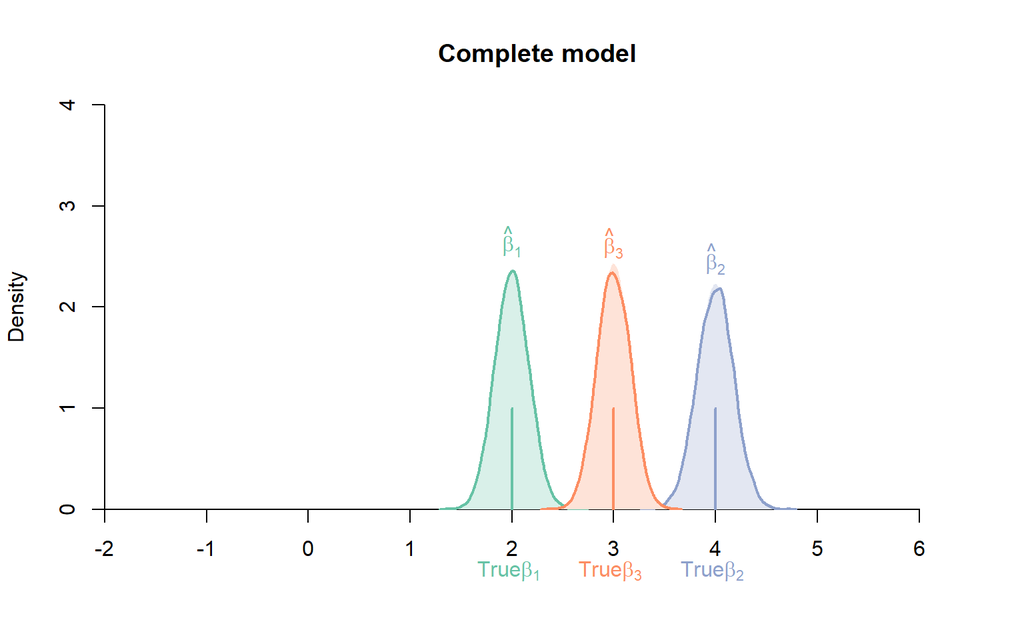

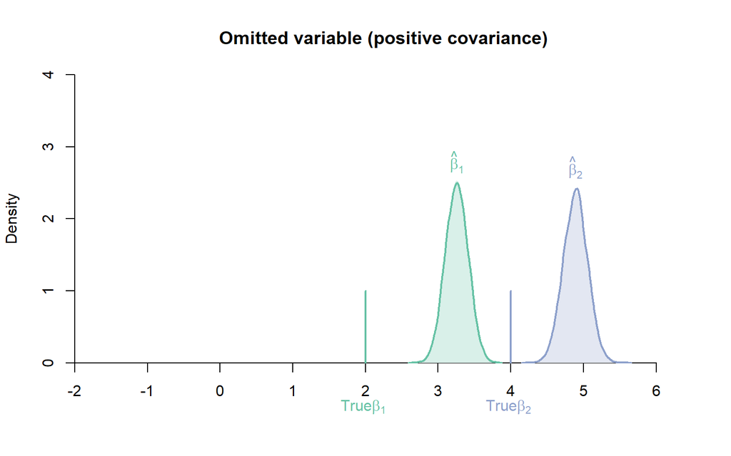

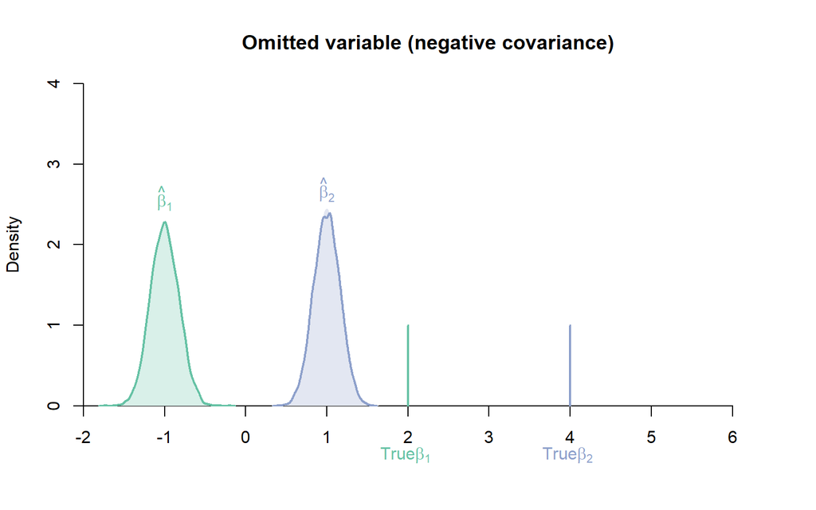

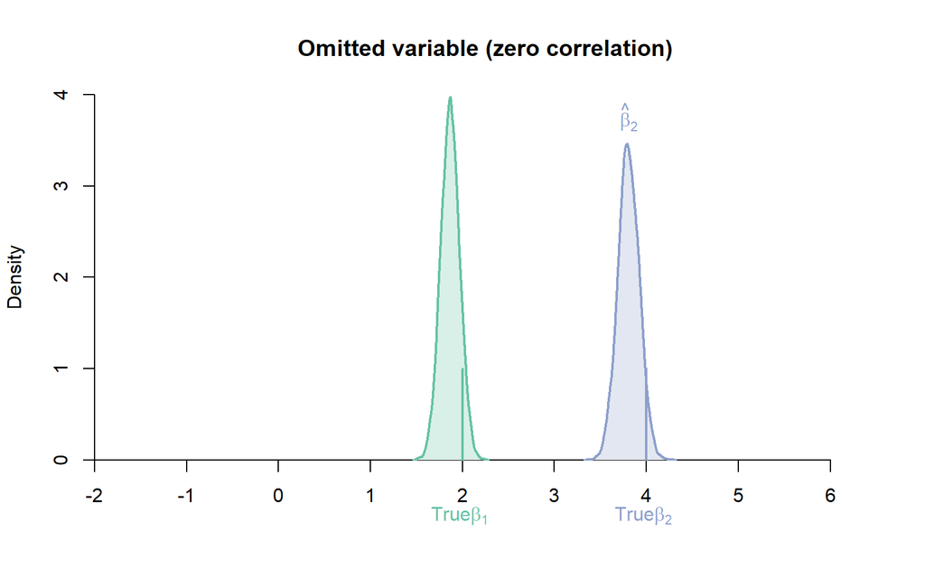

Why is this not just centered exactly around the parameter?